# Walkthrough - PCA, PLS, Clustering

Jeff

February 18, 2026

## PCA on Nutrition data

Download the nutrition data from github. It contains several thousand food items and some standard nutritional content (calories, fat, vitamins, etc) along with a food group designation. This data originates from the USDA and note that all items are measured on 100g, making observations inherently comparable.

```r
load("~/Downloads/nutrition.rdata")
dim(nutrition)
```

```
## [1] 8463   28
```

It’s noteworthy that there are some missing values in this data, but what happens if we simply remove all NA cases…

```r
dim(na.omit(nutrition))
```

```
## [1] 2184   28
```

Seems a bit extreme. Maybe we should check which columns are containing a lot of NAs…

```r
colSums(is.na(nutrition))
```

```
##          food      calories       protein carbohydrates     total_fat
##             0          3802             0             1             0
## saturated_fat      caffiene   cholesterol         fiber    folic_acid
##           340          3485           362           660          1817
##        sodium       calcium          iron     magnesium     manganese
##            83           355           146           726          2109
##        niacin    phosphorus     potassium    riboflavin      selenium
##           722           616           457           698          1757
##       thiamin     vitamin_A    vitamin_B6   vitamin_B12     vitamin_C
##           720           684           984          1233           778
##     vitamin_D          zinc         group
##          3332           744             0
```

Unfortunately, the NAs are quite spread out among several measures that we probably don’t want removed (calories for example). If we were very focused on this application, we might delve a bit further to find out why there are so many NAs, and whether they should, say, be treated as 0’s instead.

```r
nutrition <- na.omit(nutrition)
```

Always a good idea to explore the data a bit further…

```r
summary(nutrition)
```

```
##      food              calories        protein      carbohydrates
##  Length:2184        Min.   :  0.0   Min.   : 0.00   Min.   : 0.0000
##  Class :character   1st Qu.: 65.0   1st Qu.: 1.74   1st Qu.: 0.3375
##  Mode  :character   Median :171.0   Median : 7.49   Median : 8.5250
##                     Mean   :201.1   Mean   :11.48   Mean   :20.3643
##                     3rd Qu.:308.0   3rd Qu.:20.70   3rd Qu.:27.2475
##                     Max.   :876.0   Max.   :88.32   Max.   :99.7700
##    total_fat      saturated_fat         caffiene         cholesterol
##  Min.   : 0.000   Min.   : 0.00000   Min.   :   0.000   Min.   :   0.00
##  1st Qu.: 0.340   1st Qu.: 0.06075   1st Qu.:   0.000   1st Qu.:   0.00
##  Median : 3.060   Median : 0.78800   Median :   0.000   Median :   0.00
##  Mean   : 8.713   Mean   : 2.90595   Mean   :   6.731   Mean   :  39.66
##  3rd Qu.:12.383   3rd Qu.: 3.61650   3rd Qu.:   0.000   3rd Qu.:  67.00
##  Max.   :99.480   Max.   :61.92400   Max.   :5714.000   Max.   :3100.00
##      fiber          folic_acid          sodium           calcium
##  Min.   : 0.000   Min.   :  0.000   Min.   :    0.0   Min.   :   0.00
##  1st Qu.: 0.000   1st Qu.:  0.000   1st Qu.:   15.0   1st Qu.:  11.00
##  Median : 0.800   Median :  0.000   Median :   71.0   Median :  22.00
##  Mean   : 2.505   Mean   :  6.636   Mean   :  320.4   Mean   :  88.09
##  3rd Qu.: 2.800   3rd Qu.:  0.000   3rd Qu.:  325.0   3rd Qu.:  61.00
##  Max.   :79.000   Max.   :273.000   Max.   :26000.0   Max.   :7364.00
##       iron           magnesium        manganese            niacin
##  Min.   :  0.000   Min.   :  0.00   Min.   :  0.0000   Min.   : 0.000
##  1st Qu.:  0.440   1st Qu.: 12.00   1st Qu.:  0.0180   1st Qu.: 0.400
##  Median :  1.020   Median : 21.00   Median :  0.1080   Median : 1.432
##  Mean   :  2.178   Mean   : 40.61   Mean   :  0.6526   Mean   : 2.978
##  3rd Qu.:  2.320   3rd Qu.: 32.00   3rd Qu.:  0.3723   3rd Qu.: 4.769
##  Max.   :123.600   Max.   :781.00   Max.   :133.0000   Max.   :80.000
##    phosphorus       potassium         riboflavin        selenium
##  Min.   :   0.0   Min.   :    0.0   Min.   :0.0000   Min.   :   0.00
##  1st Qu.:  37.0   1st Qu.:  135.0   1st Qu.:0.0470   1st Qu.:   0.70
##  Median : 125.0   Median :  233.5   Median :0.1385   Median :   6.30
##  Mean   : 175.8   Mean   :  342.7   Mean   :0.2126   Mean   :  15.22
##  3rd Qu.: 224.0   3rd Qu.:  356.0   3rd Qu.:0.2500   3rd Qu.:  24.00
##  Max.   :9918.0   Max.   :16500.0   Max.   :6.8000   Max.   :1917.00
##     thiamin          vitamin_A         vitamin_B6      vitamin_B12
##  Min.   : 0.0000   Min.   :    0.0   Min.   :0.0000   Min.   : 0.0000
##  1st Qu.: 0.0320   1st Qu.:    0.0   1st Qu.:0.0490   1st Qu.: 0.0000
##  Median : 0.0700   Median :   22.0   Median :0.1290   Median : 0.0000
##  Mean   : 0.1855   Mean   :  847.5   Mean   :0.2395   Mean   : 0.8791
##  3rd Qu.: 0.2000   3rd Qu.:  214.0   3rd Qu.:0.3400   3rd Qu.: 0.7225
##  Max.   :10.9900   Max.   :77261.0   Max.   :8.0000   Max.   :83.1300
##    vitamin_C         vitamin_D            zinc           group
##  Min.   :   0.00   Min.   :   0.00   Min.   : 0.000   Length:2184
##  1st Qu.:   0.00   1st Qu.:   0.00   1st Qu.: 0.270   Class :character
##  Median :   0.15   Median :   0.00   Median : 0.770   Mode  :character
##  Mean   :  10.45   Mean   :  19.54   Mean   : 1.721
##  3rd Qu.:   4.10   3rd Qu.:   5.00   3rd Qu.: 2.410
##  Max.   :2400.00   Max.   :1123.00   Max.   :90.950
```

This shows us that even though food amounts were standardized, it’s pretty clear that the variables measured are on vastly different scales. As such, we should be careful to scale any PCA performed.

```r
nupca <- prcomp(nutrition[,-c(1,28)], scale.=TRUE)
summary(nupca)
```

```
## Importance of components:
##                           PC1    PC2     PC3     PC4     PC5     PC6     PC7
## Standard deviation     2.1627 1.6632 1.56431 1.32432 1.27038 1.17873 1.14213
## Proportion of Variance 0.1799 0.1064 0.09412 0.06745 0.06207 0.05344 0.05017
## Cumulative Proportion  0.1799 0.2863 0.38041 0.44786 0.50993 0.56337 0.61354
##                            PC8     PC9    PC10    PC11    PC12    PC13    PC14
## Standard deviation     1.07919 0.98092 0.95248 0.93091 0.86575 0.83505 0.81022
## Proportion of Variance 0.04479 0.03701 0.03489 0.03333 0.02883 0.02682 0.02525
## Cumulative Proportion  0.65834 0.69535 0.73024 0.76357 0.79240 0.81922 0.84446
##                           PC15    PC16    PC17   PC18    PC19    PC20   PC21
## Standard deviation     0.77617 0.76276 0.71123 0.6511 0.62883 0.60465 0.5679
## Proportion of Variance 0.02317 0.02238 0.01946 0.0163 0.01521 0.01406 0.0124
## Cumulative Proportion  0.86764 0.89001 0.90947 0.9258 0.94098 0.95504 0.9675
##                           PC22    PC23    PC24    PC25    PC26
## Standard deviation     0.55599 0.46560 0.41915 0.37748 0.04831
## Proportion of Variance 0.01189 0.00834 0.00676 0.00548 0.00009
## Cumulative Proportion  0.97934 0.98767 0.99443 0.99991 1.00000
```

Using the Kaiser criterion would suggest retaining 8 components, but that would only retain approximately 66% of the variability in the data. If we wanted to retain 90% of the variation, then we would need to keep 17 components. We can also check a scree plot

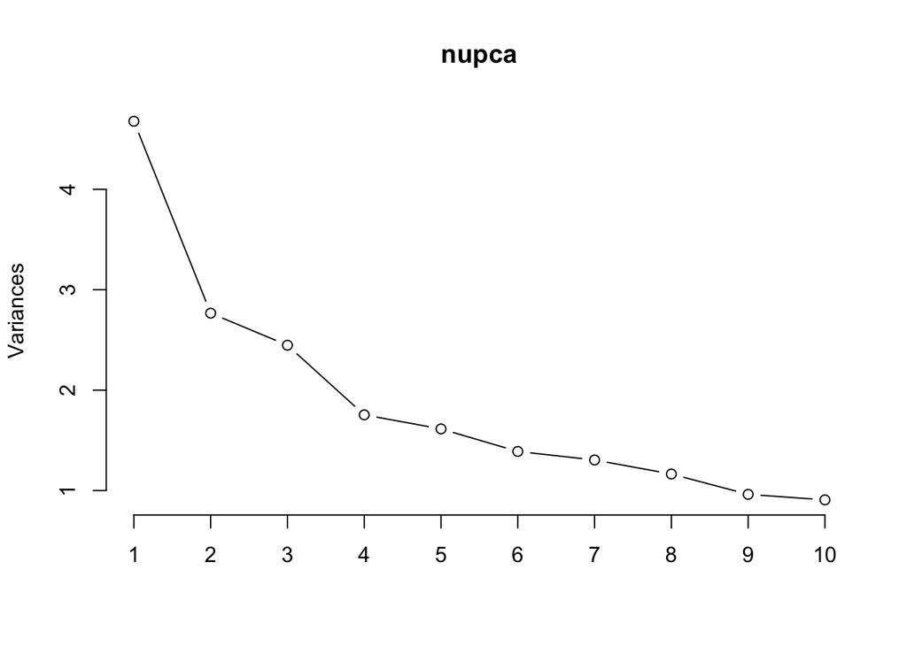

```r
plot(nupca, type="lines")
```

but by default the x-axis isn’t long enough, let’s expand

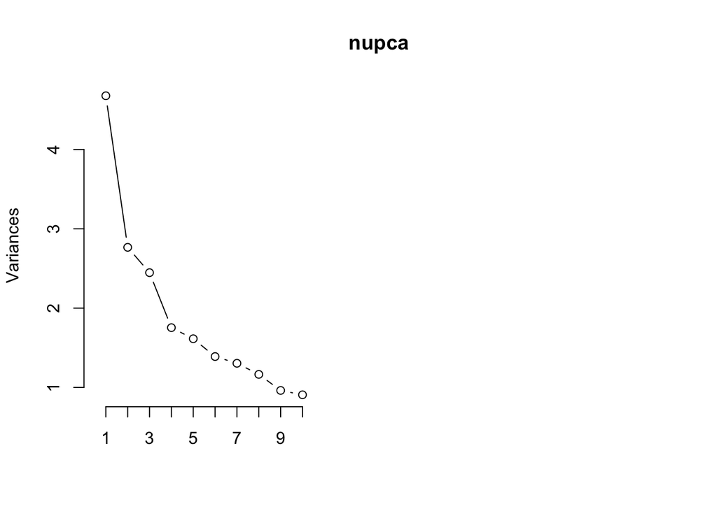

```r
plot(nupca, type="lines", xlim=c(1,26))
```

hmm, that didn’t work…little bit of searching shows that the function `screeplot` is the default `plot` method for a `prcomp` object, and the argument we want to increase is actually `npcs`…

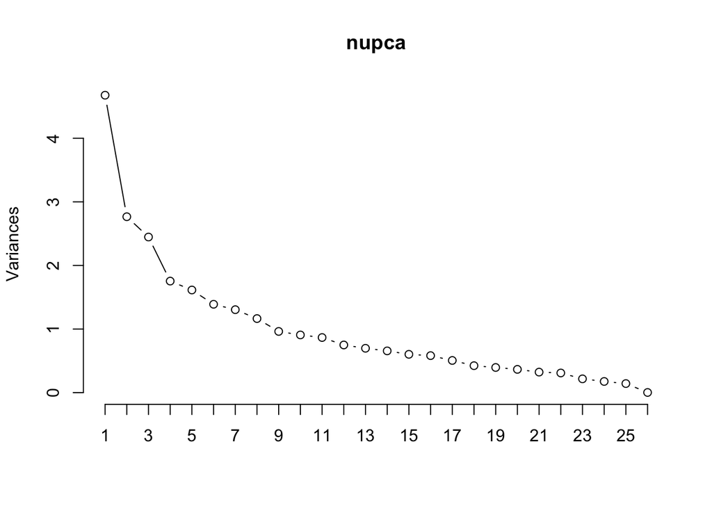

```r
plot(nupca, type="lines", npcs=26)
```

After all that work, there’s no clear picture of how many components to retain using a scree plot. Best argument might be for 3 components, but you’d be leaving a lot of variance on the table.

In any case, let’s take a look at the first three components

```r
nupca$rotation[,1:3]
```

```
##                       PC1          PC2          PC3
## calories      -0.28984450  0.071740483 -0.402817933
## protein       -0.25221736  0.304280692  0.035072126
## carbohydrates -0.13433393 -0.358147046 -0.173526769
## total_fat     -0.19967152  0.248340853 -0.410578696
## saturated_fat -0.13209879  0.269016073 -0.389903929
## caffiene      -0.06873300 -0.137864557  0.010768664
## cholesterol   -0.08102362  0.325268544  0.043743444
## fiber         -0.21811173 -0.339734033 -0.055905551
## folic_acid    -0.03832779 -0.104949921 -0.112380806
## sodium        -0.04112324  0.017210793 -0.081622954
## calcium       -0.19496728 -0.125007935 -0.085652175
## iron          -0.25405163 -0.195183474 -0.002385225
## magnesium     -0.31744573 -0.217159458 -0.081421582
## manganese     -0.13249482 -0.218888570 -0.018023030
## niacin        -0.29089205  0.136000014  0.255038615
## phosphorus    -0.23840742  0.004174599 -0.090088264
## potassium     -0.24781734 -0.212430668  0.066966641
## riboflavin    -0.29358866  0.098618291  0.261987058
## selenium      -0.11671311  0.168235553 -0.029249888
## thiamin       -0.22754623 -0.008655121  0.070734365
## vitamin_A     -0.07072538 -0.069177326  0.251779136
## vitamin_B6    -0.28627061  0.060930755  0.319147647
## vitamin_B12   -0.09624647  0.258476489  0.202930449
## vitamin_C     -0.11195416 -0.092153385  0.278167093
## vitamin_D     -0.06235645  0.173711766  0.105342221
## zinc          -0.16433946  0.154609737  0.003061607
```

To make it more readable, let’s do some rounding

```r
round(nupca$rotation[,1:3], 2)
```

```
##                 PC1   PC2   PC3
## calories      -0.29  0.07 -0.40
## protein       -0.25  0.30  0.04
## carbohydrates -0.13 -0.36 -0.17
## total_fat     -0.20  0.25 -0.41
## saturated_fat -0.13  0.27 -0.39
## caffiene      -0.07 -0.14  0.01
## cholesterol   -0.08  0.33  0.04
## fiber         -0.22 -0.34 -0.06
## folic_acid    -0.04 -0.10 -0.11
## sodium        -0.04  0.02 -0.08
## calcium       -0.19 -0.13 -0.09
## iron          -0.25 -0.20  0.00
## magnesium     -0.32 -0.22 -0.08
## manganese     -0.13 -0.22 -0.02
## niacin        -0.29  0.14  0.26
## phosphorus    -0.24  0.00 -0.09
## potassium     -0.25 -0.21  0.07
## riboflavin    -0.29  0.10  0.26
## selenium      -0.12  0.17 -0.03
## thiamin       -0.23 -0.01  0.07
## vitamin_A     -0.07 -0.07  0.25
## vitamin_B6    -0.29  0.06  0.32
## vitamin_B12   -0.10  0.26  0.20
## vitamin_C     -0.11 -0.09  0.28
## vitamin_D     -0.06  0.17  0.11
## zinc          -0.16  0.15  0.00
```

Let’s make it even more readable. Since we have lots of values here, it is often easier to view just the variables that surpass some threshold of absolute magnitude. For example…

```r
loadi <- round(nupca$rotation[,1:3], 2)
loadi[abs(loadi)<0.2] <- NA
loadi
```

```
##                 PC1   PC2   PC3
## calories      -0.29    NA -0.40
## protein       -0.25  0.30    NA
## carbohydrates    NA -0.36    NA
## total_fat     -0.20  0.25 -0.41
## saturated_fat    NA  0.27 -0.39
## caffiene         NA    NA    NA
## cholesterol      NA  0.33    NA
## fiber         -0.22 -0.34    NA
## folic_acid       NA    NA    NA
## sodium           NA    NA    NA
## calcium          NA    NA    NA
## iron          -0.25 -0.20    NA
## magnesium     -0.32 -0.22    NA
## manganese        NA -0.22    NA
## niacin        -0.29    NA  0.26
## phosphorus    -0.24    NA    NA
## potassium     -0.25 -0.21    NA
## riboflavin    -0.29    NA  0.26
## selenium         NA    NA    NA
## thiamin       -0.23    NA    NA
## vitamin_A        NA    NA  0.25
## vitamin_B6    -0.29    NA  0.32
## vitamin_B12      NA  0.26  0.20
## vitamin_C        NA    NA  0.28
## vitamin_D        NA    NA    NA
## zinc             NA    NA    NA
```

Let’s start with the first component. This component has relatively low loading of nearly all the variables. Interestingly, all of the loadings (including those below the threshold) are negative. That is, every variable in the data set is loading in the same direction. Since it doesn’t undermine the underlying mathematics, let’s multiply the first component by negative 1.

```r
loadi[,1] <- -loadi[,1]
```

Now we can reasonably interpret this component as something like “nutrient density”. We would expect any food item that scores high would be nutrient rich, and anything scoring low would be relatively void of nutrients (like water). Let’s see what the max and min food items are on this…and keep in mind that we would still need to multiply our scores by -1 since they were computed on the original loadings…

```r
head(nutrition[order(-nupca$x[,1], decreasing=TRUE),1])
```

```
## [1] "Fruit-flavored drink, powder, with high vitamin C with other added vitamins, low calorie"
## [2] "Leavening agents, yeast, baker's, active dry"
## [3] "Malted drink mix, chocolate, with added nutrients, powder"
## [4] "Rice bran, crude"
## [5] "Spices, basil, dried"
## [6] "Malted drink mix, natural, with added nutrients, powder"
```

```r
tail(nutrition[order(-nupca$x[,1], decreasing=TRUE),1])
```

```
## [1] "Carbonated beverage, low calorie, cola or pepper-type, with aspartame, without caffeine"
## [2] "Tea, herb, chamomile, brewed"
## [3] "Tea, herb, other than chamomile, brewed"
## [4] "Carbonated beverage, low calorie, other than cola or pepper, with aspartame, contains caffeine"
## [5] "Carbonated beverage, club soda"
## [6] "Carbonated beverage, low calorie, other than cola or pepper,  without caffeine"
```

On first blush this appears a bit unintuitive as most of the entries on both lists are drinks. BUT READ CLOSELY! The first, third, and sixth most nutrient “dense” are actually POWDERED drink mixes. So 100g of those probably make a substantial amount of drink, and are likely packed with sugar (hence very high in calories) and in some cases it even mentions that they have added vitamins. In fact, all of the top 6 are concentrated/dried items. The bottom six, on the other hand, are liquid drinks specifically void of most nutrients…diet pop, sparkling water, and herbal tea.

Let’s move on to the second component…

```r
loadi
```

```
##                PC1   PC2   PC3
## calories      0.29    NA -0.40
## protein       0.25  0.30    NA
## carbohydrates   NA -0.36    NA
## total_fat     0.20  0.25 -0.41
## saturated_fat   NA  0.27 -0.39
## caffiene        NA    NA    NA
## cholesterol     NA  0.33    NA
## fiber         0.22 -0.34    NA
## folic_acid      NA    NA    NA
## sodium          NA    NA    NA
## calcium         NA    NA    NA
## iron          0.25 -0.20    NA
## magnesium     0.32 -0.22    NA
## manganese       NA -0.22    NA
## niacin        0.29    NA  0.26
## phosphorus    0.24    NA    NA
## potassium     0.25 -0.21    NA
## riboflavin    0.29    NA  0.26
## selenium        NA    NA    NA
## thiamin       0.23    NA    NA
## vitamin_A       NA    NA  0.25
## vitamin_B6    0.29    NA  0.32
## vitamin_B12     NA  0.26  0.20
## vitamin_C       NA    NA  0.28
## vitamin_D       NA    NA    NA
## zinc            NA    NA    NA
```

Any item scoring high on PC2 will have high protein/fat/cholesterol/vitaminB, and low carbs/fiber/iron/magnesium/manganese/potassium. For the most part, it seems like a measure of “meatiness”. Let’s look at the top 6 and bottom 6 on this

```r
head(nutrition[order(nupca$x[,2], decreasing=TRUE),1])
```

```
## [1] "Egg, yolk, dried"
## [2] "Beef, variety meats and by-products, brain, cooked, simmered"
## [3] "Beef, variety meats and by-products, liver, cooked, pan-fried"
## [4] "Egg, whole, dried"
## [5] "Beef, variety meats and by-products, liver, cooked, braised"
## [6] "Nuts, brazilnuts, dried, unblanched"
```

```r
tail(nutrition[order(nupca$x[,2], decreasing=TRUE),1])
```

```
## [1] "Spices, cloves, ground"
## [2] "Spices, marjoram, dried"
## [3] "Spices, thyme, dried"
## [4] "Spices, basil, dried"
## [5] "Tea, instant, unsweetened, powder, decaffeinated"
## [6] "Tea, instant, unsweetened, powder"
```

For the most part our interpretation was correct (though I forgot how protein-rich and carb-less nuts were). At least one can’t get much further away from meat than unsweetened tea powder!

Finally, let’s look at component 3

```r
loadi
```

```
##                PC1   PC2   PC3
## calories      0.29    NA -0.40
## protein       0.25  0.30    NA
## carbohydrates   NA -0.36    NA
## total_fat     0.20  0.25 -0.41
## saturated_fat   NA  0.27 -0.39
## caffiene        NA    NA    NA
## cholesterol     NA  0.33    NA
## fiber         0.22 -0.34    NA
## folic_acid      NA    NA    NA
## sodium          NA    NA    NA
## calcium         NA    NA    NA
## iron          0.25 -0.20    NA
## magnesium     0.32 -0.22    NA
## manganese       NA -0.22    NA
## niacin        0.29    NA  0.26
## phosphorus    0.24    NA    NA
## potassium     0.25 -0.21    NA
## riboflavin    0.29    NA  0.26
## selenium        NA    NA    NA
## thiamin       0.23    NA    NA
## vitamin_A       NA    NA  0.25
## vitamin_B6    0.29    NA  0.32
## vitamin_B12     NA  0.26  0.20
## vitamin_C       NA    NA  0.28
## vitamin_D       NA    NA    NA
## zinc            NA    NA    NA
```

Anything scoring high on this component will be low in calories and fat, but high in vitamins. So generally speaking, let’s just call it “vitamin-dense”.

```r
head(nutrition[order(nupca$x[,3], decreasing=TRUE),1])
```

```
## [1] "Fruit-flavored drink, powder, with high vitamin C with other added vitamins, low calorie"
## [2] "Peppers, sweet, red, freeze-dried"
## [3] "Beef, variety meats and by-products, liver, cooked, pan-fried"
## [4] "Beef, variety meats and by-products, liver, cooked, braised"
## [5] "Malted drink mix, chocolate, with added nutrients, powder"
## [6] "Malted drink mix, natural, with added nutrients, powder"
```

```r
tail(nutrition[order(nupca$x[,3], decreasing=TRUE),1])
```

```
## [1] "Pork, fresh, backfat, raw"
## [2] "Butter, whipped, with salt"
## [3] "Butter, without salt"
## [4] "Butter, salted"
## [5] "Nuts, coconut meat, dried (desiccated), not sweetened"
## [6] "Butter oil, anhydrous"
```

The bottom six are no brainers (basically just fat-based items), but the top six are again a bit strange. We have, once more, our powdered drink mixes, freeze dried peppers, and beef liver!

## PCAReg on Nutrition data

Let’s continue with the nutrition data. We’ll keep the same lazy cleaning again just to keep things easy.

```r
#load("~/Downloads/nutrition.rdata")
#dim(nutrition)
#nutrition <- na.omit(nutrition)
colnames(nutrition)
```

```
##  [1] "food"          "calories"      "protein"       "carbohydrates"
##  [5] "total_fat"     "saturated_fat" "caffiene"      "cholesterol"
##  [9] "fiber"         "folic_acid"    "sodium"        "calcium"
## [13] "iron"          "magnesium"     "manganese"     "niacin"
## [17] "phosphorus"    "potassium"     "riboflavin"    "selenium"
## [21] "thiamin"       "vitamin_A"     "vitamin_B6"    "vitamin_B12"
## [25] "vitamin_C"     "vitamin_D"     "zinc"          "group"
```

Now then, to set this up in a PCRegression type context, we’ll need a natural continuous response variable. I think `calories` is likely the most natural approach since they can come primarily from both fat and carbs. As such, we will need to remove it from the original PCA call.

```r
nupca <- prcomp(nutrition[,-c(1,2,28)], scale.=TRUE)
summary(nupca)
```

```
## Importance of components:
##                           PC1    PC2     PC3    PC4     PC5     PC6     PC7
## Standard deviation     2.0905 1.6613 1.45197 1.2787 1.24728 1.17387 1.13369
## Proportion of Variance 0.1748 0.1104 0.08433 0.0654 0.06223 0.05512 0.05141
## Cumulative Proportion  0.1748 0.2852 0.36953 0.4349 0.49715 0.55227 0.60368
##                            PC8     PC9    PC10    PC11    PC12    PC13    PC14
## Standard deviation     1.07393 0.98081 0.95224 0.92905 0.85969 0.83157 0.78987
## Proportion of Variance 0.04613 0.03848 0.03627 0.03453 0.02956 0.02766 0.02496
## Cumulative Proportion  0.64982 0.68830 0.72457 0.75909 0.78865 0.81631 0.84127
##                           PC15    PC16    PC17    PC18    PC19    PC20   PC21
## Standard deviation     0.77604 0.76121 0.70758 0.64976 0.62872 0.59025 0.5678
## Proportion of Variance 0.02409 0.02318 0.02003 0.01689 0.01581 0.01394 0.0129
## Cumulative Proportion  0.86536 0.88854 0.90856 0.92545 0.94126 0.95520 0.9681
##                           PC22    PC23    PC24    PC25
## Standard deviation     0.53484 0.46515 0.40082 0.36685
## Proportion of Variance 0.01144 0.00865 0.00643 0.00538
## Cumulative Proportion  0.97954 0.98819 0.99462 1.00000
```

Again, using the Kaiser criterion would suggest retaining 8 components, but that would only retain approximately 65% of the variability in the data. In the previous lab we investigated the other standard approaches for component retention…let’s not bother for this lab. We’ll retain the first 8 components. So, let’s pop the scores of the original observations on those 8 components into an object for future use.

```r
scr <- nupca$x[,1:8]
```

Now we can run PCReg for calories as a response…

```r
pcregmod <- lm(nutrition$calories ~ scr)
summary(pcregmod)
```

```
##
## Call:
## lm(formula = nutrition$calories ~ scr)
##
## Residuals:
##     Min      1Q  Median      3Q     Max
## -624.91  -40.83  -10.22   29.49  236.46
##
## Coefficients:
##             Estimate Std. Error t value Pr(>|t|)
## (Intercept) 201.1200     1.5068 133.475  < 2e-16 ***
## scrPC1       35.9805     0.7210  49.907  < 2e-16 ***
## scrPC2        5.0377     0.9072   5.553 3.15e-08 ***
## scrPC3       51.3592     1.0380  49.479  < 2e-16 ***
## scrPC4       26.6879     1.1787  22.642  < 2e-16 ***
## scrPC5      -55.3065     1.2083 -45.770  < 2e-16 ***
## scrPC6       20.3169     1.2839  15.824  < 2e-16 ***
## scrPC7       28.3220     1.3294  21.304  < 2e-16 ***
## scrPC8       22.3124     1.4034  15.899  < 2e-16 ***
## ---
## Signif. codes:  0 '***' 0.001 '**' 0.01 '*' 0.05 '.' 0.1 ' ' 1
##
## Residual standard error: 70.42 on 2175 degrees of freedom
## Multiple R-squared:  0.7969, Adjusted R-squared:  0.7962
## F-statistic:  1067 on 8 and 2175 DF,  p-value: < 2.2e-16
```

Cool! Everything appears interesting and useful for modelling. Of course, our PCA was done unsupervised — therefore, without respect to what we were trying to model (calories). So perhaps PLS can help us improve…

## PLS on nutrition

We will need the `pls` library here

```r
#install.packages("pls")
library(pls)
```

Now, we will feed the function `plsr` a formula for calories as a response to all other numeric predictors.

```r
nuplsmod <- plsr(calories~., data=nutrition[,-c(1,28)], scale=TRUE, method="oscorespls")
summary(nuplsmod)
```

```
## Data:    X dimension: 2184 25
##  Y dimension: 2184 1
## Fit method: oscorespls
## Number of components considered: 25
## TRAINING: % variance explained
##           1 comps  2 comps  3 comps  4 comps  5 comps  6 comps  7 comps
## X           14.53    24.29    29.77    34.48    42.06    47.18    51.29
## calories    69.29    89.08    94.64    97.56    98.41    99.10    99.35
##           8 comps  9 comps  10 comps  11 comps  12 comps  13 comps  14 comps
## X           53.93    58.15     62.05     65.75     68.60     71.63     74.91
## calories    99.48    99.51     99.51     99.51     99.52     99.52     99.52
##           15 comps  16 comps  17 comps  18 comps  19 comps  20 comps  21 comps
## X            77.47     79.78     82.71     84.67     86.75     89.30     92.12
## calories     99.52     99.52     99.52     99.52     99.52     99.52     99.52
##           22 comps  23 comps  24 comps  25 comps
## X            94.66     96.10     97.89    100.00
## calories     99.52     99.52     99.52     99.52
```

This gives a very different picture…namely that it appears probably 2 components are sufficient (cumulatively explain just over 89% of the variation in `calories`). Compare that to PCReg — 8 components explained only 79% of the variation in `calories`. Clearly an improvement. In fact, if we only take the first two components for PCReg…

```r
pcregmod2 <- lm(nutrition$calories ~ scr[,1:2])
summary(pcregmod2)
```

```
##
## Call:
## lm(formula = nutrition$calories ~ scr[, 1:2])
##
## Residuals:
##     Min      1Q  Median      3Q     Max
## -887.77  -92.51  -45.45   74.04  646.03
##
## Coefficients:
##               Estimate Std. Error t value Pr(>|t|)
## (Intercept)    201.120      2.920  68.888   <2e-16 ***
## scr[, 1:2]PC1   35.981      1.397  25.758   <2e-16 ***
## scr[, 1:2]PC2    5.038      1.758   2.866   0.0042 **
## ---
## Signif. codes:  0 '***' 0.001 '**' 0.01 '*' 0.05 '.' 0.1 ' ' 1
##
## Residual standard error: 136.4 on 2181 degrees of freedom
## Multiple R-squared:  0.2355, Adjusted R-squared:  0.2348
## F-statistic: 335.8 on 2 and 2181 DF,  p-value: < 2.2e-16
```

Only 23%! Hence why PLS is generally a superior approach in a supervised context.

## Caution

But how would even PLS compare to a domain-wise and straightforward model…

```r
dwmod <- lm(calories~total_fat+carbohydrates, data=nutrition)
summary(dwmod)
```

```
##
## Call:
## lm(formula = calories ~ total_fat + carbohydrates, data = nutrition)
##
## Residuals:
##     Min      1Q  Median      3Q     Max
## -151.58  -40.60  -10.91   36.02  310.91
##
## Coefficients:
##               Estimate Std. Error t value Pr(>|t|)
## (Intercept)   49.95804    1.47220   33.93   <2e-16 ***
## total_fat      9.63835    0.07792  123.69   <2e-16 ***
## carbohydrates  3.29893    0.03917   84.22   <2e-16 ***
## ---
## Signif. codes:  0 '***' 0.001 '**' 0.01 '*' 0.05 '.' 0.1 ' ' 1
##
## Residual standard error: 47.3 on 2181 degrees of freedom
## Multiple R-squared:  0.9081, Adjusted R-squared:  0.908
## F-statistic: 1.078e+04 on 2 and 2181 DF,  p-value: < 2.2e-16
```

Just slightly more of the variation (90.8% versus 89.1%) in `calories` can be explained using an equivalent dimensionality from the original variables.

In machine learning, there is often no substitute for domain-knowledge!

## Single linkage chaining

Let’s simulate a weird data set with 2 clusters and a line of points running in between. We’ll use manhattan distance for no particular reason other than showing how to specify it…

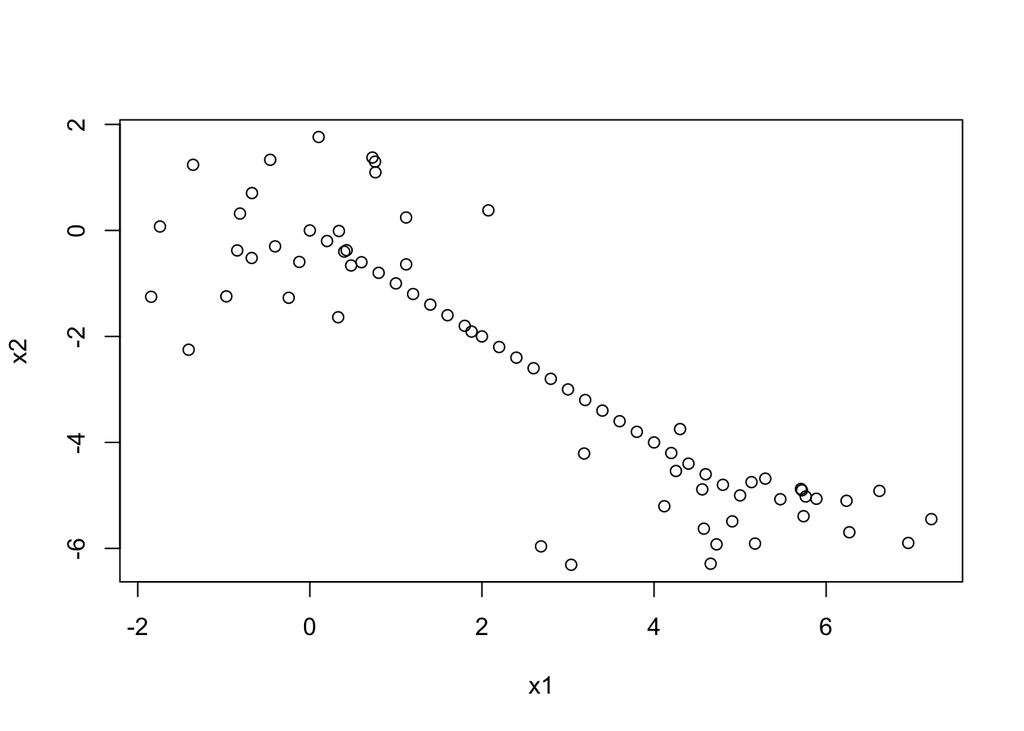

```r
library(MASS)
set.seed(3173)
datagen1 <- mvrnorm(25, c(0,0), matrix(c(1,0,0,1),2,2))
datagen2 <- mvrnorm(25, c(5,-5), matrix(c(1,0,0,1),2,2))
datagen <- rbind(datagen1, datagen2)
x1 <- seq(from=0, to=5, by=0.2)
x2 <- seq(from=0, to=-5, by=-0.2)
newvalx <- cbind(x1,x2)
datagen <- rbind(datagen,newvalx)
plot(datagen)
```

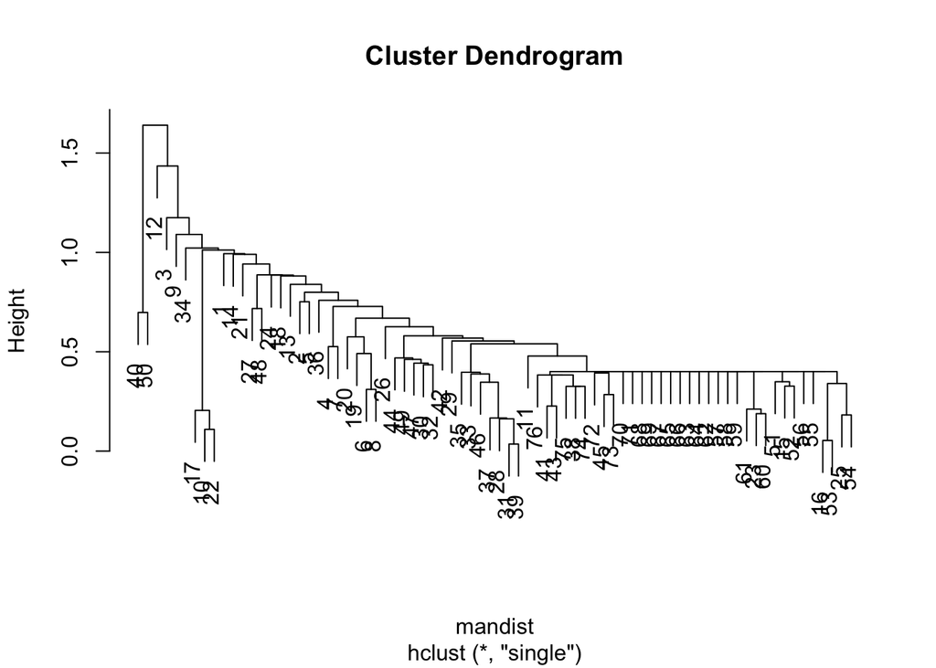

```r
mandist <- dist(datagen,method="manhattan")
clus1 <- hclust(mandist, method="single")
plot(clus1)
```

Using single linkage we have major difficulty finding an underlying group structure. The plot above is a tell-tale sign of the phenomena called “chaining” — essentially that you keep adding observations to one group for the majority of the algorithm. This problem tends to only be a concern with single linkage…

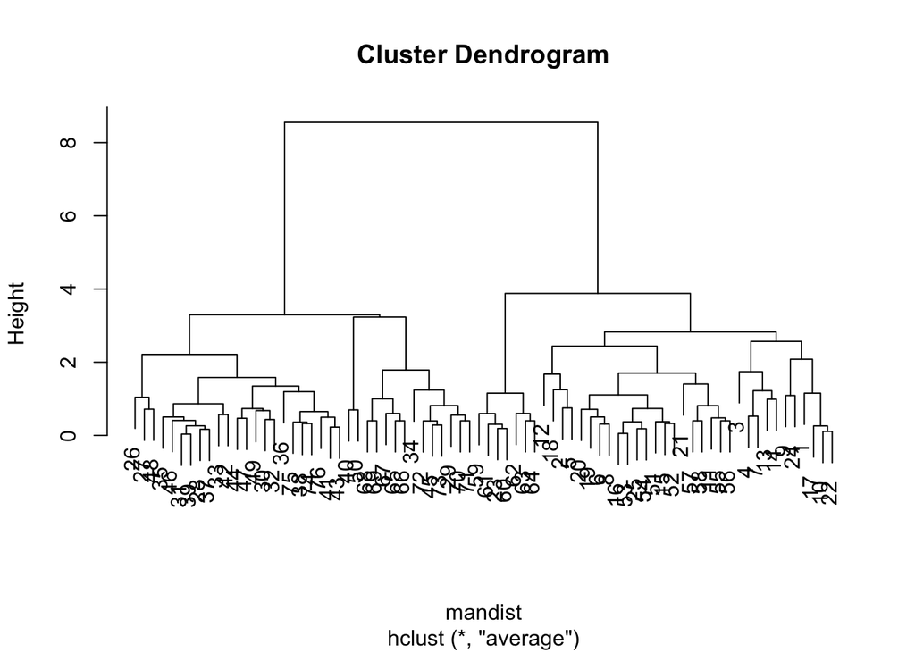

```r
clus2 <- hclust(mandist, method="average")
plot(clus2)
```

Note that switching to euclidean distance doesn’t fix the chaining issue, but does result in slightly different groups

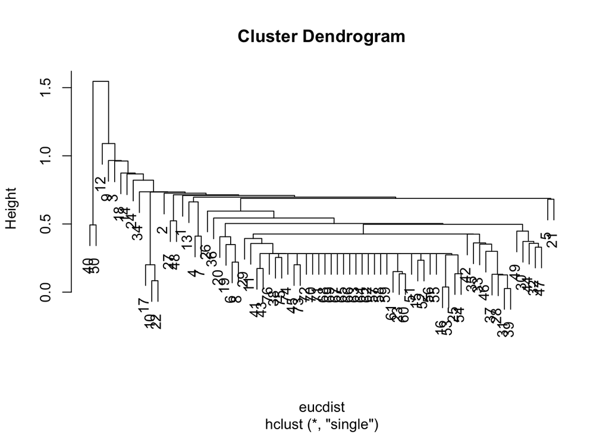

```r
eucdist <- dist(datagen,method="euclidean")
clus3 <- hclust(eucdist, method="single")
plot(clus3)
```

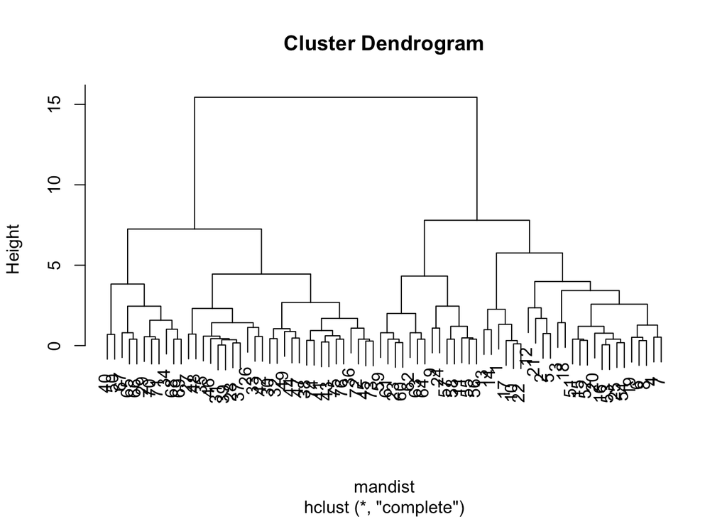

```r
#Euclidean, complete
clus4 <- hclust(mandist, method="complete")
plot(clus4)
```

```r
mancom <- cutree(clus2,2)
euccom <- cutree(clus4,2)
table(mancom,euccom)
```

```
##       euccom
## mancom  1  2
##      1 39  0
##      2  0 37
```

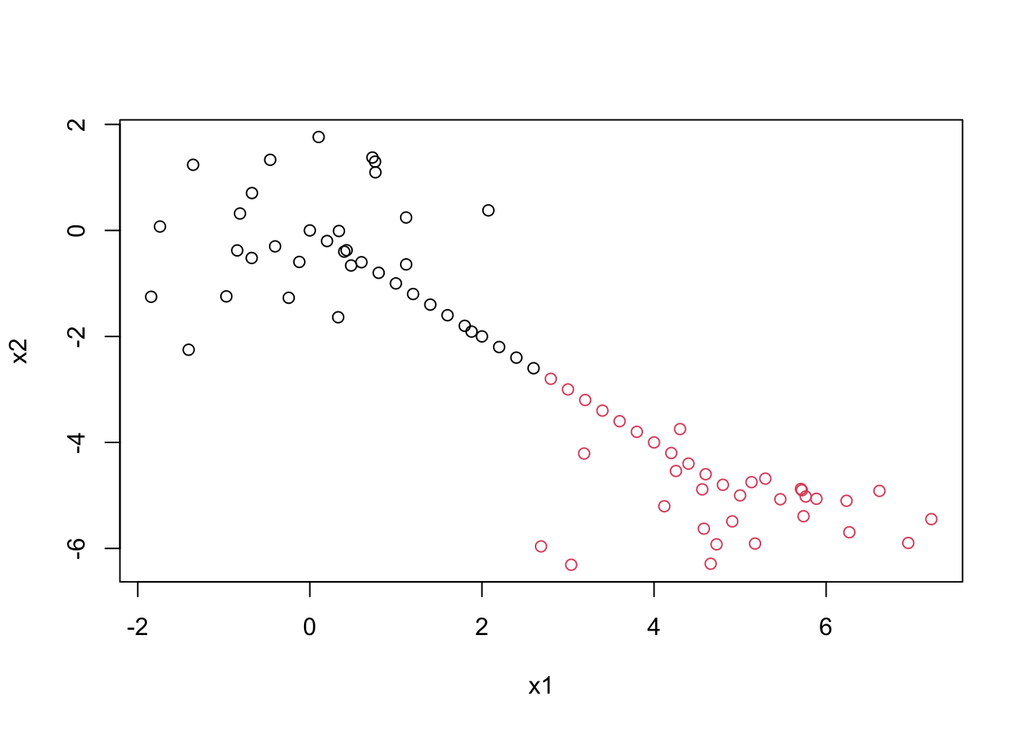

```r
plot(datagen, col=mancom)
```

Now euclidean with single linkage, and we will compare the results with euclidean with complete linkage.

```r
eucsin <- cutree(clus3,2)
table(euccom,eucsin)
```

```
##       eucsin
## euccom  1  2
##      1 39  0
##      2 35  2
```

Single linkage makes two groups, one with only two observations in it!

## Kmeans

Let’s code up k-means from scratch. We should be able to provide the function with the data `x` and the number of groups `k`.

It’s probably best to remind you of the steps of the kmeans algorithm first: 1. Start with `k` random centroids (let’s use points within the data) 2. Assign all observations to their closest centroid (by euclidean distance) 3. Recalculate group means. Call these your new centroids. 4. Repeat 2, 3 until nothing changes.

There are several ways of going about this. Sometimes its easier to just code the actual steps and then back up to setup the loop, etc, but I’ll provide the whole thing, with some comments to point out what we’re accomplishing with each chunk of the code.

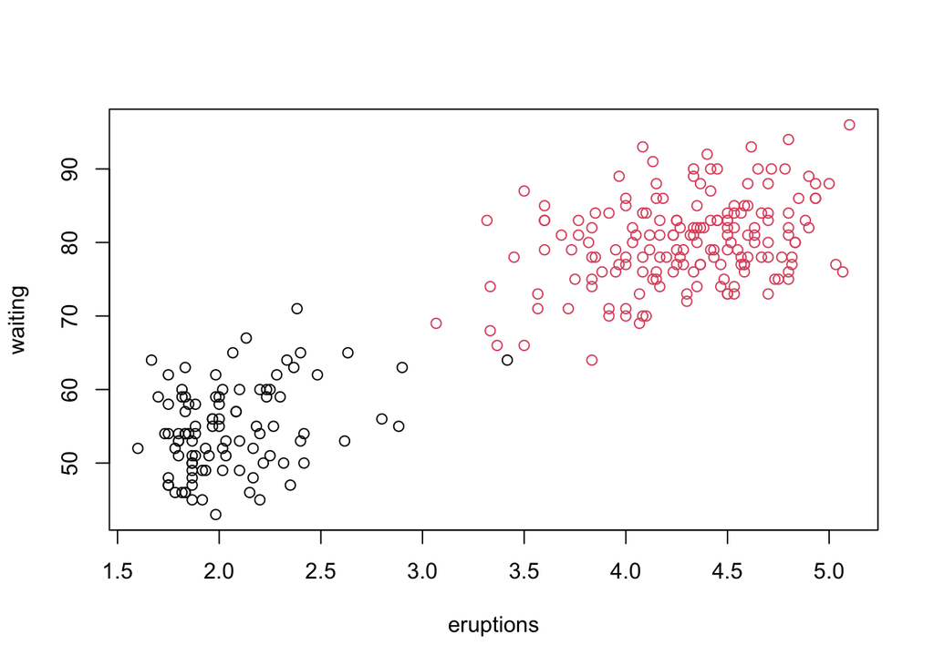

```r
my_k_means <- function(x, k){
  #1 start with k centroids
  centrs <- x[sample(1:nrow(x), k),]
  #start loop
  changing <- TRUE
  while(changing){
    #2a) calculate distances between all x and centrs
    dists <- matrix(NA, nrow(x), k)
    #could write as a double loop, or could utilize other built in functions probably
    for(i in 1:nrow(x)){
      for(j in 1:k){
        dists[i, j] <- sqrt(sum((x[i,] - centrs[j,])^2))
      }
    }
    #2b) assign group memberships (you probably want to provide some overview of apply functions)
    membs <- apply(dists, 1, which.min)

    #3) calculate new group centroids
    oldcentrs <- centrs #save for convergence check!
    for(j in 1:k){
      centrs[j,] <- colMeans(x[membs==j, ])
    }

    #4) check for convergence
    if(all(centrs==oldcentrs)){
      changing <- FALSE
    }
  }
  #output memberships
  membs
}

set.seed(5314)
#debug(my_k_means) #if you want
test <- my_k_means(scale(faithful), 2)
plot(faithful, col=test)
```

Compare to the built in version…

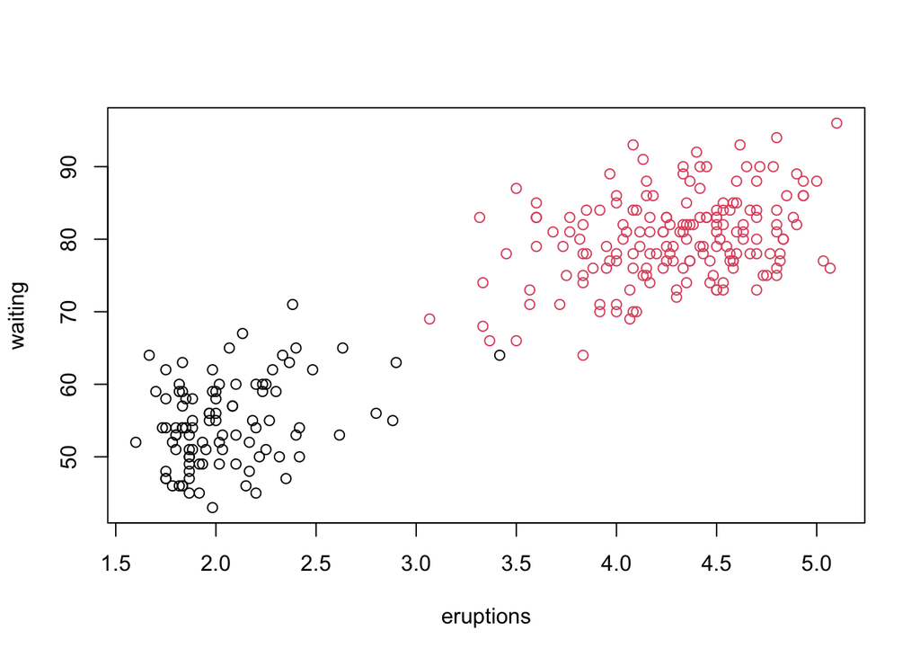

```r
test2 <- kmeans(scale(faithful), 2)
plot(faithful, col=test2$cl)
```

## Mouse simulation

We’ll talk more about this in the next week or so, but here’s a very simple way to see some of the hidden assumptions of k-means in action.

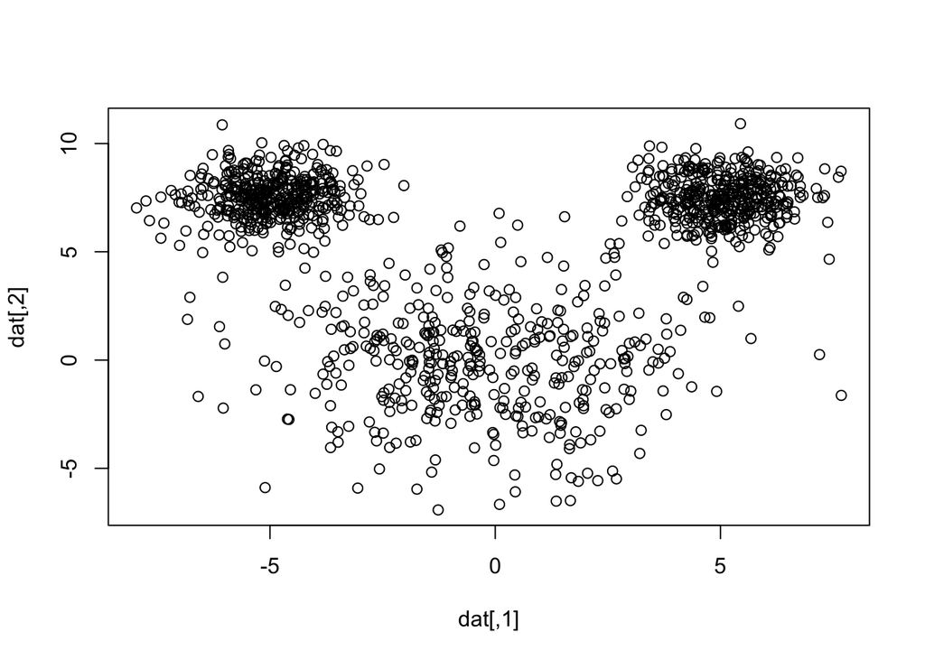

```r
library(mvtnorm)
set.seed(35151)
le <- rmvnorm(400, mean = c(-5,7.5))
re <- rmvnorm(400, mean = c(5,7.5))
hd <- rmvnorm(400, mean = c(0,0), sigma=7*diag(2) )
dat <- rbind(le, re, hd)
plot(dat)
```

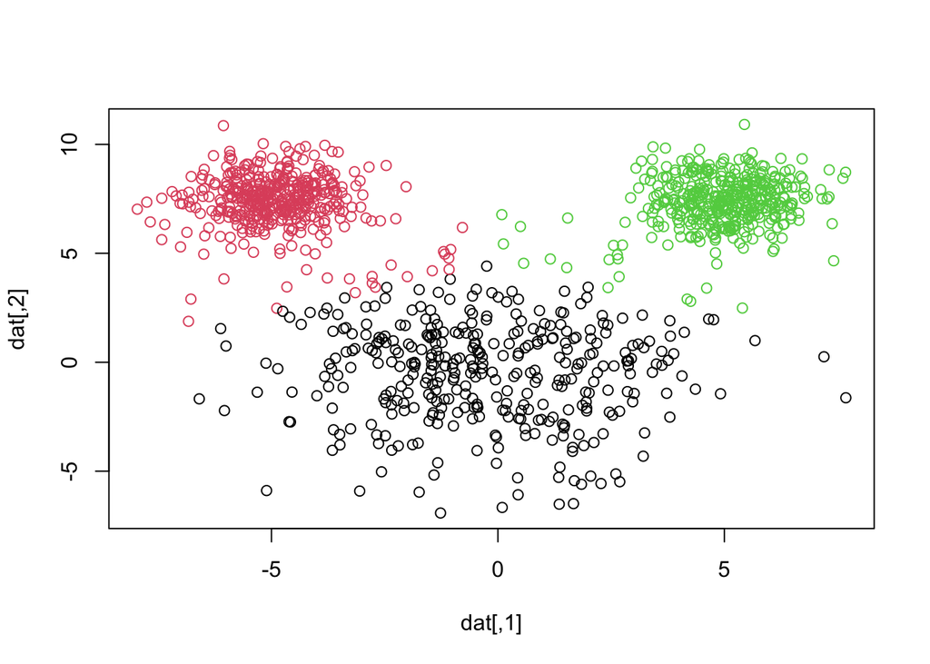

```r
mickres <- my_k_means(scale(dat), 3)
plot(dat, col=mickres)
```

Note how the smaller mouse ears are assumed larger in k-means, even though the groups are relatively well-separated. We can see this by showing a side by side of the truth and what k-means just gave us

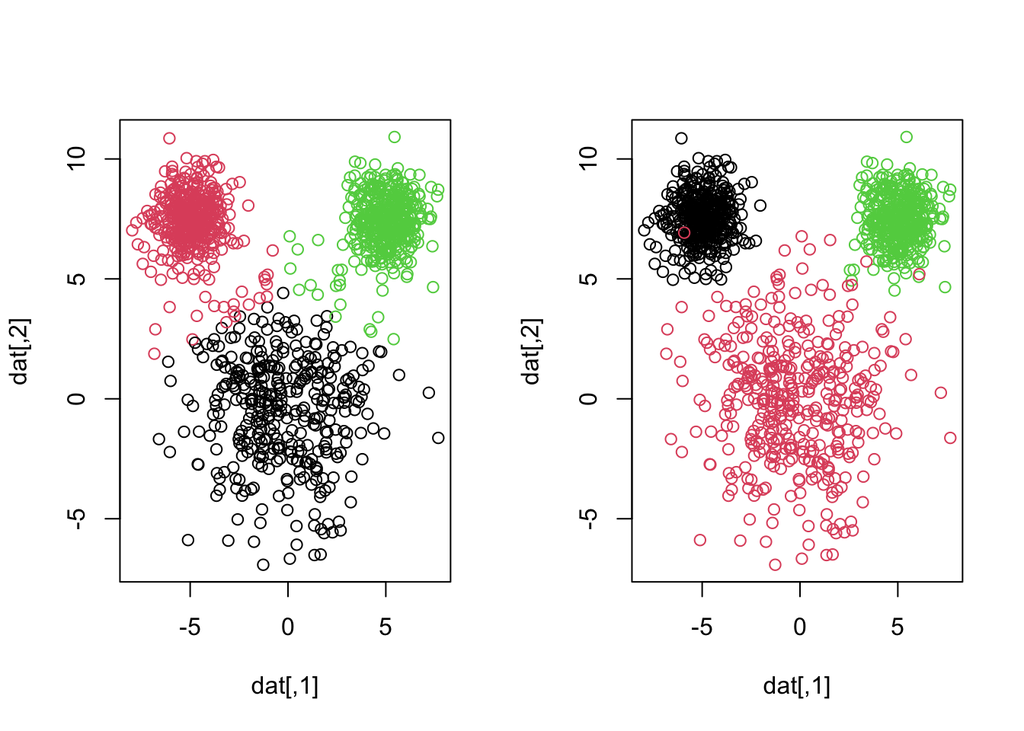

```r
par(mfrow=c(1,2))
plot(dat, col=mickres)
plot(dat, col=rep(c(1,3,2), each=400))
```

What about heirarchical?

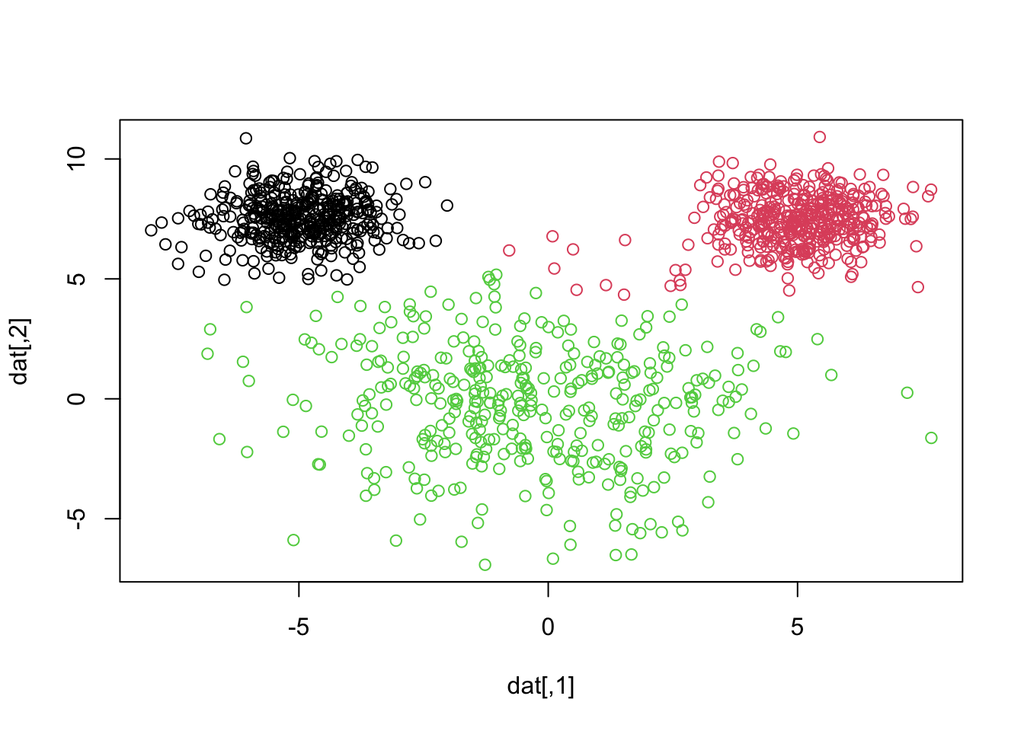

```r
mickdist <- dist(scale(dat))
mickhc <- hclust(mickdist, method="average")
mickhcres <- cutree(mickhc, 3)
plot(dat, col=mickhcres)
```

Still not perfect, but not as bad. Some of the other linkage options are worse than what results from k-means as well.